# Analyze FACS data

## 6.2 Assign sample names and other metadata

`r`r sampleNames(flowData) <- SampleSheet$Strain

|  | name | Well | Strain | Genotype | Ploidy | Media |
| --- | --- | --- | --- | --- | --- | --- |
| DGY1 | E07.fcs | E07 | DGY1 | 0 copy control | 1N | YPD |
| DGY500 | E08.fcs | E08 | DGY500 | 1 copy control | 1N | YPD |
| DGY1315 | E09.fcs | E09 | DGY1315 | 2 copy control | 1N | YPD |
| DGY1657 | E10.fcs | E10 | DGY1657 | GAP1 reporter | 1N | YPD |
| DGY1658 | E11.fcs | E11 | DGY1658 | GAP1 reporter | 1N | YPD |
| DGY1972 | E12.fcs | E12 | DGY1972 | 1 copy @ HO | 1N | YPD |
| DGY1973 | F07.fcs | F07 | DGY1973 | 1 copy @ HO | 1N | YPD |
| DGY1974 | F08.fcs | F08 | DGY1974 | 1 copy @ HO | 1N | YPD |
| DGY2000 | F09.fcs | F09 | DGY2000 | 2 copy HO/endo | 1N | YPD |
| DGY2001 | F10.fcs | F10 | DGY2001 | 2 copy HO/endo | 1N | YPD |

[output cut: 9 more lines]

## 6.3 View a summary of the data

`r`r fsApply(flowData,each_col,median)

```
           FSC.A    SSC.A    FL1.A FL2.A   FL3.A FL4.A     FSC.H    SSC.H    FL1.H FL2.H   FL3.H FL4.H Width Time
DGY1    708025.0 111357.5   1872.0   278   676.0   245 1075001.5 151600.0   3510.0   271  1412.0   514    60  163
DGY500  706858.0 115767.5 184357.5  1822 13254.0  1728 1116047.5 164725.0 185777.0  1832 13520.0  1821    58  159
DGY1315 673867.5 109442.0 341691.0  3279 24630.0  3113 1113197.5 162067.5 357620.0  3464 25968.0  3332    56  160
DGY1657 678571.0 108559.5 176388.0  1779 12802.0  1697 1119643.5 161552.5 184336.0  1828 13496.5  1814    57  161
DGY1658 636788.0  97018.0 166741.0  1732 12166.0  1650 1058990.5 144904.5 173839.5  1744 12755.0  1738    56  165
DGY1972 646497.0  96580.5 174775.0  1940 12803.0  1848  966048.0 131518.5 160255.5  1673 11701.0  1722    59  212
DGY1973 635552.0  99823.0 162894.0  1673 11871.0  1596 1063489.0 147454.0 171547.0  1711 12584.0  1705    56  163
DGY1974 678989.5 107215.0 178133.5  1769 12872.0  1675 1115865.0 157109.0 185850.5  1854 13642.0  1819    57  158
DGY2000 635213.5  98545.0 330682.0  3259 23905.0  3101 1044707.5 144460.0 343191.0  3337 24881.0  3226    56  167
DGY2001 663436.0 105325.5 357938.0  3455 25850.0  3265 1101761.0 155297.0 373337.0  3614 27152.0  3472    57  164
DGY2135 622491.5  97634.0 145818.5  1527 10744.0  1449 1068373.0 147587.5 158968.5  1608 11773.5  1591    55  162
DGY2136 658949.0  99015.0 151732.5  1647 11252.0  1576 1100384.0 145737.0 161010.5  1641 11883.0  1649    56  176
DGY2143 634325.0 107630.5 172070.0  1750 12671.0  1655 1090845.0 163739.0 187101.0  1873 13858.0  1832    55  159
DGY2144 570371.0  85767.0 136492.5  1392  9962.0  1318 1006540.5 132717.0 153739.5  1528 11311.0  1506    53  158
DGY2148 650177.0 102916.5 291186.5  2815 21183.0  2653 1105639.0 154959.0 315504.0  3070 23151.0  2935    55  160
DGY2158 612864.0  91176.0 283469.0  2852 20535.0  2713 1036767.5 134779.0 307042.0  2993 22198.5  2886    55  186
DGY2236 662816.0  96799.0 325685.5  3354 23486.0  3180  990074.0 129721.5 297907.5  2963 21411.0  2916    60  208
DGY2237 458943.0  67538.0 281142.5  2876 20468.5  2741  788130.0 100189.0 292073.5  2873 21159.5  2799    51  198
DGY2238 483209.0  75201.5 266791.0  2750 19323.5  2624  804562.5 108990.5 273765.5  2700 19754.0  2641    53  206
```

`r`r #data_summary <- as_tibble(fsApply(flowData,each_col,median)) #names(data_summary)

## 6.4 Visualization using the `ggcyto` package

### 6.4.1 Using Autoplot

`autoplot()` is a simple function that provides quick plots of the data with minimal control on the appearance of the plot

#### 6.4.1.1 Ploting a single channel

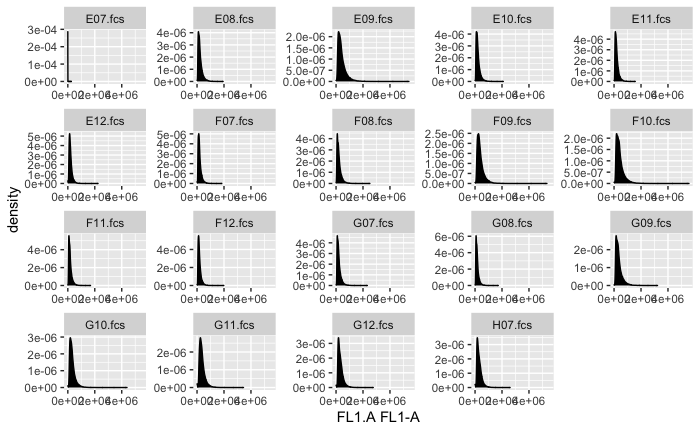

#### 6.4.1.2 Plotting two channels

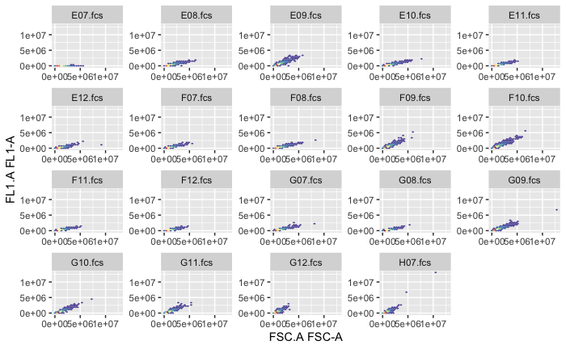

### 6.4.2 Using the `ggcyto` function

`ggcyto` provides more control over the plot

#### 6.4.2.1 Ploting a single channel

`r`r p <- ggcyto(flowData, aes(x = FL1.A)) p + geom_histogram() + scale_x_flowjo_biexp()

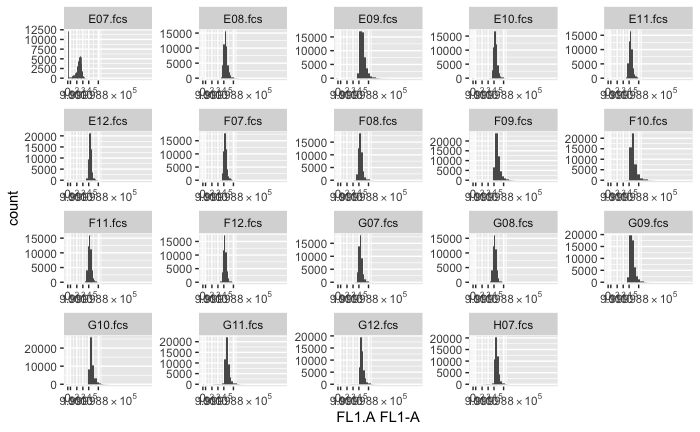

#### 6.4.2.2 Using `ggridges`

`r`r p + scale_x_logicle() + geom_density_ridges(aes(y = Strain)) + facet_null() #facet_null is used to remove the default facet_wrap (by ‘name’ column)

[figure not shown]

#### 6.4.2.3 2D Scatter plots

`r`r p <- ggcyto(flowData, aes(x = `FSC.A`, y = `FL1.A`)) p + geom_hex(bins = 128)

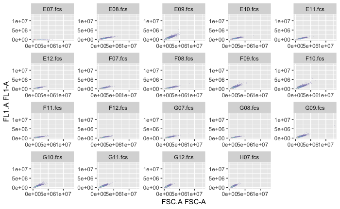

### 6.4.3 Using ggplot

`r`r ggplot(data = flowData, aes(x = FL1.A/FSC.A)) + geom_histogram()

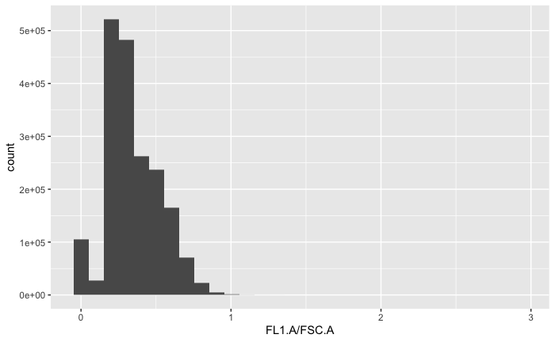